# ps05

Karina Yang

2023-02-17

#INFO201 Problem Set: rmarkdown and plotting **1 Load and check data (5pt)** You first task is to do a very simple data check: 1. (1pt) For solving the problems, and answering the questions, create a new rmarkdown docu- ment with an appropriate title. See https://faculty.washington.edu/otoomet/info201-book/ r-markdown.html#r-markdown-rstudio-creating 2. (2pt) Load data. How many rows/columns do we have?

```r
library(dplyr)
library(readr)
df <- read_delim("gapminder.csv")
nrow(df)
```

```
## [1] 13055
```

```r
ncol(df)
```

```
## [1] 25
```

3. (2pt) Print a small sample of data. Does it look OK?

```r
head(df)
```

```
## # A tibble: 6 × 25
##   iso3  name  iso2  region sub-r…¹ inter…²  time total…³ ferti…⁴ lifeE…⁵ child…⁶
##   <chr> <chr> <chr> <chr>  <chr>   <chr>   <dbl>   <dbl>   <dbl>   <dbl>   <dbl>
## 1 ABW   Aruba AW    Ameri… Latin … Caribb…  1960   54211    4.82    65.7      NA
## 2 ABW   Aruba AW    Ameri… Latin … Caribb…  1961   55438    4.66    66.1      NA
## 3 ABW   Aruba AW    Ameri… Latin … Caribb…  1962   56225    4.47    66.4      NA
## 4 ABW   Aruba AW    Ameri… Latin … Caribb…  1963   56695    4.27    66.8      NA
## 5 ABW   Aruba AW    Ameri… Latin … Caribb…  1964   57032    4.06    67.1      NA
## 6 ABW   Aruba AW    Ameri… Latin … Caribb…  1965   57360    3.84    67.4      NA
## # … with 14 more variables: youthFemaleLiteracy <dbl>, youthMaleLiteracy <dbl>,
## #   adultLiteracy <dbl>, GDP_PC <dbl>, accessElectricity <dbl>,
## #   agriculturalLand <dbl>, agricultureTractors <dbl>, cerealProduction <dbl>,
## #   fertilizerHa <dbl>, co2 <dbl>, greenhouseGases <dbl>, co2_PC <dbl>,
## #   pm2.5_35 <dbl>, battleDeaths <dbl>, and abbreviated variable names
## #   ¹`sub-region`, ²`intermediate-region`, ³totalPopulation, ⁴fertilityRate,
## #   ⁵lifeExpectancy, ⁶childMortality
```

**2 Descriptive statistics (15pt)** 1. (3pt) How many countries are there in the dataset? Analyze all three: iso3, iso2 and name.

```r
length(unique(df$name))
```

```
## [1] 250
```

```r
length(unique(df$iso2))
```

```
## [1] 249
```

```r
length(unique(df$iso3))
```

```
## [1] 253
```

2. If you did this correctly, you saw that there are more names than iso-2 codes, and there are even more iso3 -codes. What is going on? Can you find it out?
1. (5pt) Find how many names are there for each iso-2 code. Are there any iso-2 codes that correspond to more than one name? What are these countries?

```r
df %>%
  group_by(iso2) %>%
  summarise(n = n_distinct(name)) %>%
  arrange(desc(n))
```

```
## # A tibble: 249 × 2
##    iso2      n
##    <chr> <int>
##  1 <NA>      2
##  2 AD        1
##  3 AE        1
##  4 AF        1
##  5 AG        1
##  6 AI        1
##  7 AL        1
##  8 AM        1
##  9 AO        1
## 10 AQ        1
## # … with 239 more rows
```

2. (5pt) Now repeat the same for name and iso3-code. Are there country names that have more than one iso3-code? What are these countries? Hint: two of these entitites are CHANISL and NLD CURACAO.

```r
df %>%
  group_by(name) %>%
  summarise(n2 = n_distinct(iso3)) %>%
  arrange(desc(n2))
```

```
## # A tibble: 250 × 2
##    name                   n2
##    <chr>               <int>
##  1 <NA>                    4
##  2 Afghanistan             1
##  3 Albania                 1
##  4 Algeria                 1
##  5 American Samoa          1
##  6 Andorra                 1
##  7 Angola                  1
##  8 Anguilla                1
##  9 Antarctica              1
## 10 Antigua and Barbuda     1
## # … with 240 more rows
```

```r
df %>%
  filter(is.na(name)) %>%
  distinct(iso3)
```

```
## # A tibble: 4 × 1
##   iso3
##   <chr>
## 1 CHANISL
## 2 GBM
## 3 KOS
## 4 NLD_CURACAO
```

3. (2pt) What is the minimum and maximum year in these data?

```r
df %>%
  filter(!is.na(time)) %>%
  summarise(max_year = max(time), min_year = min(time))
```

```
## # A tibble: 1 × 2
##   max_year min_year
##      <dbl>    <dbl>
## 1     2019     1960
```

**3 CO2 emissions (30pt)** Next, let’s analyze CO2 emissions. 1. (2pt) How many missing co2 emissions are there for each year? Analyze both missing CO2 and co2_PC. Which years have most missing data?

```r
length(df$co2 == "NA")
```

```
## [1] 13055
```

2. (5pt) Make a plot of total CO2 emissions over time for the U.S, China, and India. Add a few more countries of your choice. Explain what do you see.

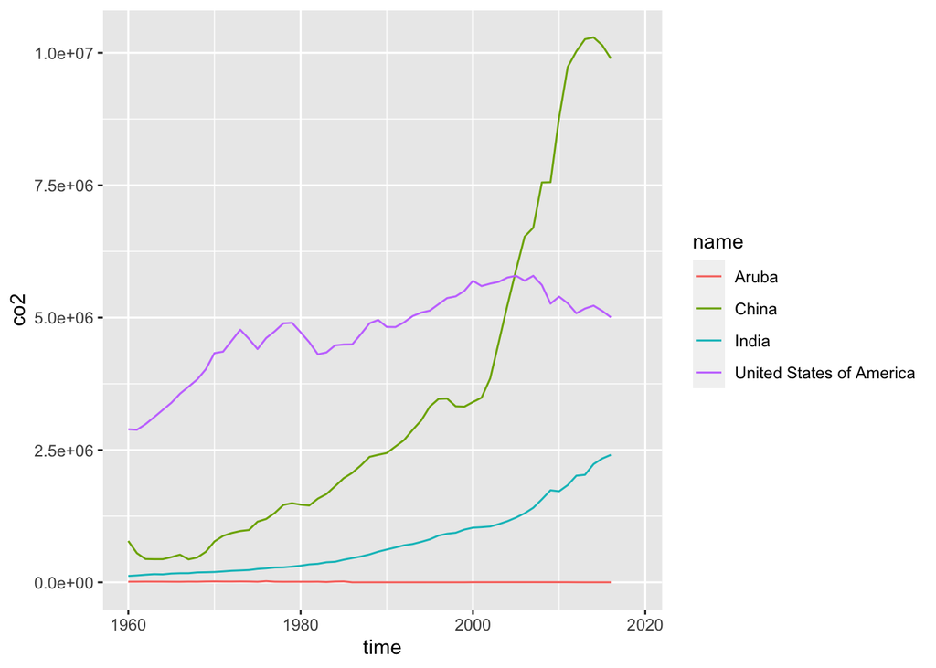

```r
library(ggplot2)
df %>%
  filter(name == "United States of America" |name == "China" | name == "India" | name == "Aruba") %>%
  select(time, co2, name) %>%
  ggplot(aes(x = time, y = co2, color = name)) +
  geom_line()
```

3. (5pt) Now let’s analyze the CO2 emissions per capita (co2_PC ). Make a similar plot of the same countries. What does this figure suggest?

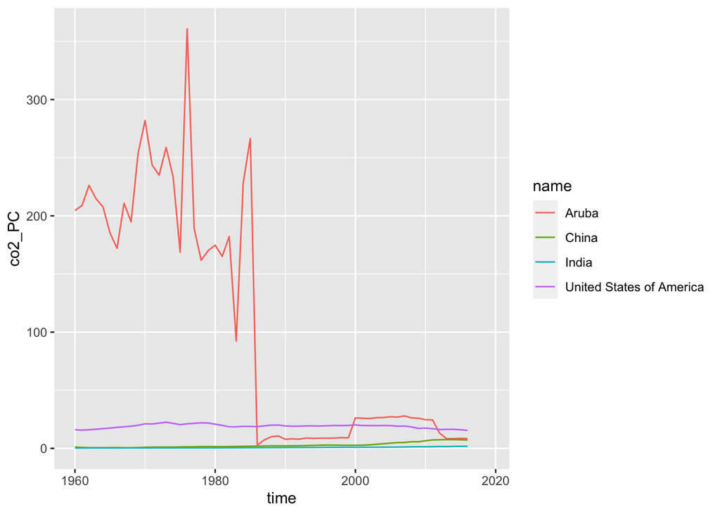

```r
df %>%
  filter(name == "United States of America" |name == "China" | name == "India" | name == "Aruba") %>%
  select(time, co2_PC, name) %>%
  ggplot(aes(x = time, y = co2_PC, color = name)) +
  geom_line()
```

4. (6pt) Compute average CO2 emissions per capita across the continents (assume region is the same as continent). Comment what do you see. Note: just compute averages over countries and ignore the fact that countries are of different size.

```r
df %>%
  filter(!is.na(co2_PC), !is.na(region)) %>%
  group_by(region,time) %>%
  summarize(avg_co2_pc = mean(co2_PC))
```

```
## # A tibble: 285 × 3
## # Groups:   region [5]
##    region  time avg_co2_pc
##    <chr>  <dbl>      <dbl>
##  1 Africa  1960      0.291
##  2 Africa  1961      0.300
##  3 Africa  1962      0.299
##  4 Africa  1963      0.310
##  5 Africa  1964      0.349
##  6 Africa  1965      0.385
##  7 Africa  1966      0.422
##  8 Africa  1967      0.607
##  9 Africa  1968      0.781
## 10 Africa  1969      0.824
## # … with 275 more rows
```

Hint: Americas 2016 should be 4.80. 5. (7pt) Make a barplot where you show the previous results–average CO2 emissions per capita across continents in 1960 and 2016.Hint: it should look something along these lines:

```r
avg_co2_pc <- df %>%
  filter(!is.na(co2_PC), !is.na(region)) %>%
  group_by(region, time) %>%
  summarize(avg_co2_pc = mean(co2_PC))
```

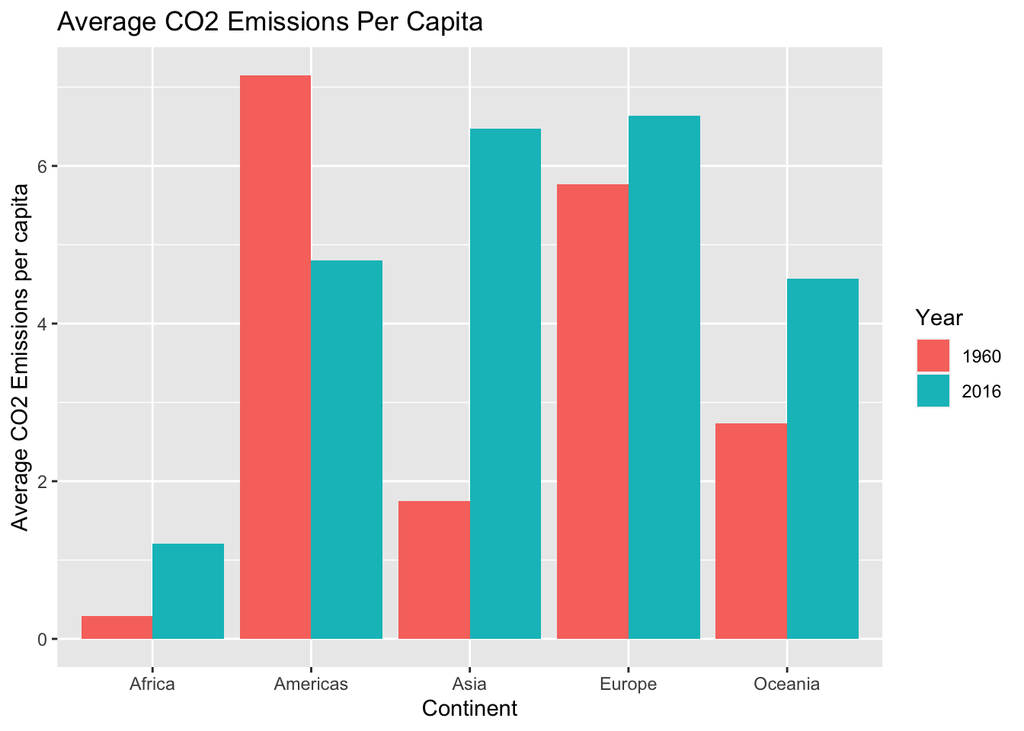

[output not shown]

```r
ggplot(avg_co2_pc %>% filter(time %in% c(1960, 2016)), aes(x = region, y = avg_co2_pc, fill = factor(time))) +
  geom_col(position = "dodge") +
  labs(title = "Average CO2 Emissions Per Capita",
       x = "Continent",
       y = "Average CO2 Emissions per capita",
       fill = "Year")
```

```r
#There is no data in 2019 so I use 1960
#largest
df %>%
  filter(time == 1960) %>%
  filter(!is.na(co2_PC), !is.na(region)) %>%
  group_by(region) %>%
  summarise(avg = mean(co2_PC)) %>%
  arrange(desc(avg)) %>%
  head(3)
```

```
## # A tibble: 3 × 2
##   region     avg
##   <chr>    <dbl>
## 1 Americas  7.15
## 2 Europe    5.77
## 3 Oceania   2.73
```

```r
#smallest
df %>%
  filter(time == 1960, !is.na(co2_PC), !is.na(region)) %>%
  group_by(region) %>%
  summarise(avg = mean(co2_PC)) %>%
  arrange(desc(avg)) %>%
  tail(3)
```

```
## # A tibble: 3 × 2
##   region    avg
##   <chr>   <dbl>
## 1 Oceania 2.73
## 2 Asia    1.74
## 3 Africa  0.291
```

**4 GDP per capita (50pt)** Let’s look at GDP per capita (GDP_PC ). 1. (8pt) Make a scatterplot of GDP per capita versus life expectancy by country, using data for 1960. Make the point size dependent on the country size, and color those according to the continent. Feel free to adjust the plot in other ways to make it better. Comment what do you see there.

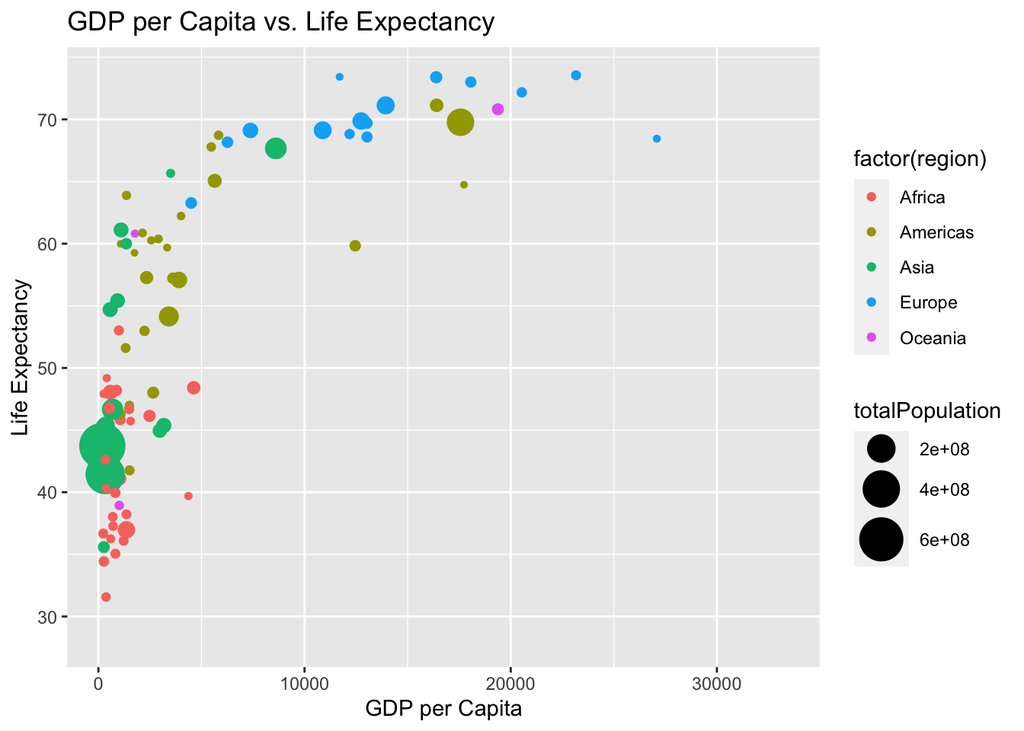

```r
df_1960 <- df %>% filter(time == 1960, !is.na(name))

ggplot(df_1960, aes(x = GDP_PC, y = lifeExpectancy, size = totalPopulation, color = factor(region))) +
  geom_point() +
  scale_size_continuous(range = c(1, 10)) +
  labs(title = "GDP per Capita vs. Life Expectancy", x = "GDP per Capita", y = "Life Expectancy")
```

2. (4pt) Make a similar plot, but this time use 2019 data only.

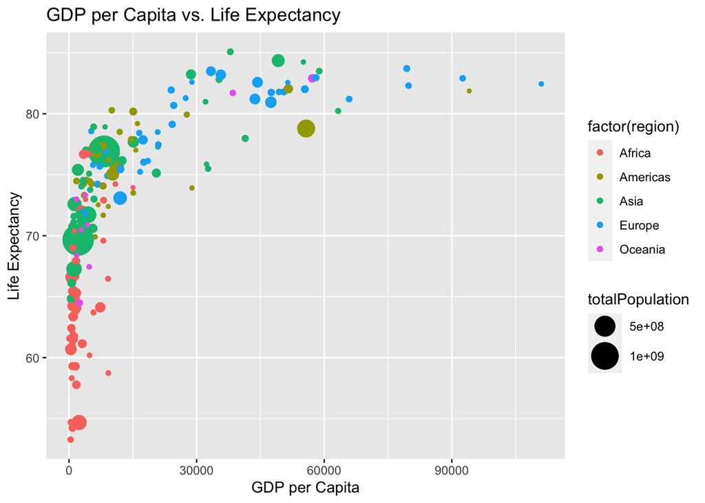

```r
df_2019 <- df %>% filter(time == 2019, !is.na(name))
ggplot(df_2019, aes(x = GDP_PC, y = lifeExpectancy, size = totalPopulation, color = factor(region))) +
  geom_point() +
  scale_size_continuous(range = c(1, 10)) +
  labs(title = "GDP per Capita vs. Life Expectancy", x = "GDP per Capita", y = "Life Expectancy")
```

```r
df %>%
  filter(time == 1960 | time == 2019, !is.na(region)) %>%
  group_by(region, time) %>%
  summarize(mean_le = mean(lifeExpectancy, na.rm = TRUE))
```

```
## # A tibble: 10 × 3
## # Groups:   region [5]
##    region    time mean_le
##    <chr>    <dbl>   <dbl>
##  1 Africa    1960    41.5
##  2 Africa    2019    64.1
##  3 Americas  1960    58.6
##  4 Americas  2019    75.8
##  5 Asia      1960    51.6
##  6 Asia      2019    74.6
##  7 Europe    1960    68.3
##  8 Europe    2019    79.4
##  9 Oceania   1960    56.4
## 10 Oceania   2019    73.5
```

5. (8pt) Compute the average LE growth from 1960-2019 across the continents. Show the results in the order of growth. Explain what do you see. Hint: these data (data in long form) is not the simplest to compute growth. But you may want to check out the lag() function. And do not forget to group data by continent when using lag(), otherwise your results will be messed up! See https://faculty.washington. edu/otoomet/info201-book/dplyr.html#dplyr-helpers-compute.

```r
df %>%
  filter(time == 1960 | time == 2019,
         !is.na(region)) %>%
  group_by(region, time) %>%
  summarize(mean_le = mean(lifeExpectancy, na.rm = TRUE)) %>%
  mutate(dif = mean_le - lag(mean_le)) %>%
  filter(!is.na(dif)) %>%
  select(region, dif) %>%
  arrange(desc(dif)) %>%
  print()
```

```
## # A tibble: 5 × 2
## # Groups:   region [5]
##   region     dif
##   <chr>    <dbl>
## 1 Asia      23.0
## 2 Africa    22.6
## 3 Americas  17.2
## 4 Oceania   17.1
## 5 Europe    11.1
```

6. (6pt) Show the histogram of GDP per capita for years of 1960 and 2019. Try to put both histograms on the same graph, see how well you can do it!

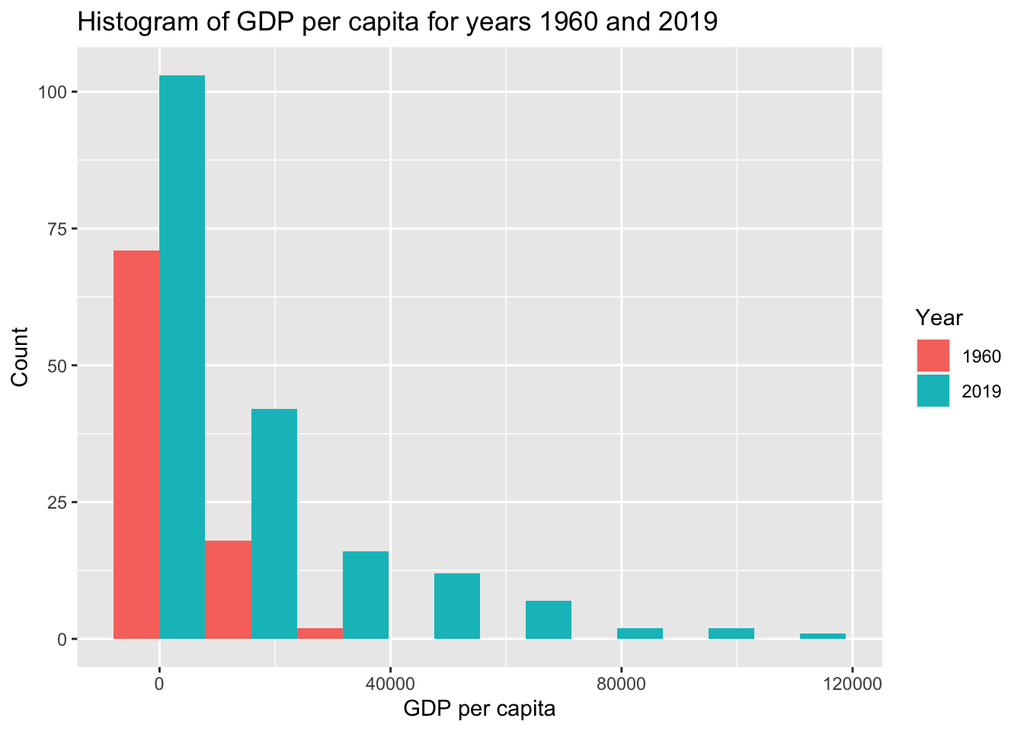

```r
gapminder_1960_2019 <- df %>%
  filter(time %in% c(1960, 2019))

ggplot(gapminder_1960_2019, aes(x=GDP_PC, fill=factor(time))) +
  geom_histogram(position = "dodge", bins = 8) +
  ggtitle("Histogram of GDP per capita for years 1960 and 2019") +
  labs(x="GDP per capita", y="Count", fill = "Year")
```

7. (6pt) What was the ranking of US in terms of life expectancy in 1960 and in 2019? (When counting from top.) Hint: check out the function rank()! Hint2: 17 for 1960.

```r
df %>%
  filter(time == 1960 | time == 2019) %>%
  filter(!is.na(name)) %>%
  group_by(time) %>%
  mutate(rank = rank(desc(lifeExpectancy))) %>%
  filter(iso3 == "USA") %>%
  select(time, lifeExpectancy, rank, name) %>%
  print()
```

```
## # A tibble: 2 × 4
## # Groups:   time [2]
##    time lifeExpectancy  rank name
##   <dbl>          <dbl> <dbl> <chr>
## 1  1960           69.8    17 United States of America
## 2  2019           78.8    46 United States of America
```

8. (6pt) If you did this correctly, then you noticed that US ranking has been falling quite a bit. But we also have more countries in 2019–what about the relative rank divided by the corresponding number of countries that have LE data in the corresponding year? Hint: 0.0904 for 1960.

```r
num_countries <- df %>%
  filter(!is.na(lifeExpectancy)) %>%
  filter(!is.na(name)) %>%
  group_by(time) %>%
  summarise(n_countries = n())

us_rank <- df %>%
  filter(!is.na(name) & !is.na(lifeExpectancy)) %>%
  group_by(time) %>%
  mutate(rank = rank(desc(lifeExpectancy))) %>%
  filter(iso3 == "USA") %>%
  select(time, rank)

result <- left_join(num_countries, us_rank, by = "time") %>%
  mutate(rel_rank = rank / n_countries)

result
```

```
## # A tibble: 60 × 4
##     time n_countries  rank rel_rank
##    <dbl>       <int> <dbl>    <dbl>
##  1  1960         188    17   0.0904
##  2  1961         189    14   0.0741
##  3  1962         189    17   0.0899
##  4  1963         188    20   0.106
##  5  1964         188    22   0.117
##  6  1965         189    21   0.111
##  7  1966         189    26   0.138
##  8  1967         189    21   0.111
##  9  1968         189    32   0.169
## 10  1969         189    25   0.132
## # … with 50 more rows
```

**Finally tell us how many hours did you spend on this PS.** I spent 10 hrs on this assignment.